# Data Visualization I

2023-12-02

## An Introduction to **{ggplot2}**

Being able to create graphical representations of data is key to being able to communication information and findings to others. Visualizing data is not just key to communicating information to others, in fact, it is a key aspect of exploratory data analysis. For most of us, graphics make it easier to identify patterns, trends, and outliers in data (big or small).

In this module, we will learn to use **{ggplot2}** a library from the **{tidyverse}** that allows us to declaratively make beautiful plots or charts from data. While R does provide built-in plotting functions out of the box, **{ggplot2}** is particularly effective at allowing users to make nearly any kind of static data visualizations and customize these to their exact expectations.

See: https://ggplot2.tidyverse.org/

Before we move forward, let’s take a look at a finalized graph created using **{ggplot2}**:

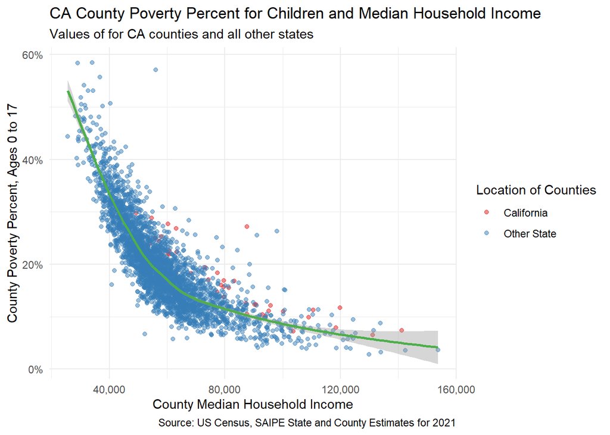

```r
library(dplyr)
library(ggplot2)

all_counties <- rcahelpr::saipe_state_and_county %>%
  # Notice that the state and nation `County FIPS Code` is "000"
  filter(`County FIPS Code` != "000") %>%
  # Select and rename:
  select(name = Name,
         postal = `Postal Code`,
         poverty_percent_0_17 = `Poverty Percent, Age 0-17`,
         median_household_income = `Median Household Income`) %>%
  # If observation is CA then return a TRUE for all values
  mutate(is_ca = if_else(postal == "CA", "California", "Other State"))

ggplot(data = all_counties,
             aes(y = poverty_percent_0_17,
                 x = median_household_income,
                 color = is_ca)) +
  geom_point(alpha = 0.5, size = 1.5) +
  geom_smooth(color = "#4daf4a") +
  labs(title = element_text("CA County Poverty Percent for Children and Median Household Income"),
       subtitle = "Values of for CA counties and all other states",
       caption = "Source: US Census, SAIPE State and County Estimates for 2021",
       color = "Location of Counties",
       x = "County Median Household Income",
       y = "County Poverty Percent, Ages 0 to 17") +
  scale_color_brewer(palette = "Set1", type = "qual") +
  scale_x_continuous(labels = scales::comma) +
  scale_y_continuous(labels = scales::percent_format(scale = 1)) +
  theme_minimal()
```

What do we have here?

- Each point represents a county (nationwide) where the median household income for the county is mapped to the x position and the poverty percent for ages 0-17 is mapped to the y position.
- The line represents the dominant pattern for nationwide data.
- Some dots represent California counties where the median household income for the county is mapped to the x position and the poverty percent for ages 0-17 is mapped to the y position.

Here we will walk through how to set up something this complex.

## Start with data + a quick review of **{dplyr}**

For this exercise we will use data from the **{rcahelpr}** package, which needs to be re-installed as the data was updated and your local version may be outdated:

```r
remotes::install_github("cllghn/rcahelpr", force = TRUE)
```

The particular data set that we will use is called `saipe_state_and_county` within the package and it includes information about estimates of poverty and income at the County and State level for 2021. It was obtained from the US Census and manipulated to trim down the number of variables in the data. You can access the data by loading the **{rcahelpr}** library:

```r
library(rcahelpr)
head(saipe_state_and_county)
```

```
##   State FIPS Code County FIPS Code Postal Code           Name
## 1              00              000          US  United States
## 2              01              000          AL        Alabama
## 3              01              001          AL Autauga County
## 4              01              003          AL Baldwin County
## 5              01              005          AL Barbour County
## 6              01              007          AL    Bibb County
##   Poverty Estimate, All Ages Poverty Percent, All Ages
## 1                   41393176                      12.8
## 2                     800848                      16.3
## 3                       6296                      10.7
## 4                      25526                      10.8
## 5                       5089                      23.0
## 6                       4204                      20.6
##   Poverty Estimate, Age 0-17 Poverty Percent, Age 0-17
```

[output cut: 20 more lines]

The variables are mostly self-explanatory, but some can use some clarification: - `State FIPS Code` and `County FIPS Code` are numbers which uniquely identify geographic areas. - `Postal Code` is a two-letter Postal State abbreviation. - `Name` represents the state or county name. - `Poverty Estimate, All Ages`: Estimate of people of all ages in poverty - `Poverty Percent, All Ages`: Estimated percent of people of all ages in poverty - `Poverty Estimate, Age 0-17`: Estimate of people age 0-17 in poverty - `Poverty Percent, Age 0-17`: Estimated percent of people age 0-17 in poverty - `Poverty Estimate, Age 5-17 in Families`: Estimate of related children age 5-17 in families in poverty - `Poverty Percent, Age 5-17 in Families`: Estimated percent of related children age 5-17 in families in poverty - `Median Household Income`: Estimate of median household income

As you can see, we can do many things with the data. Our goal is to answer: How is the median household income related to the the poverty percent for people age 0-18 in poverty? How is the median household income related to the the poverty percent for people age 0-18 in poverty in California? We will try to answer some of these questions and in the process learn how to create some basic plots in **{ggplot2}**.

However, before we get started, we need to trim our data to make it more manageable and reshape it a little. For example:

- The data contains observations for states and the country, we are only interested in counties.
- The variable names are not named using snakecase and the spacing makes it harder to work with.
- Add a logical variable specifying if an observation corresponds to CA or not.

Lucky for us, we are **{dplyr}** geniuses and know how to leverage the `filter()` function to subset our rows (observations) based on specific parameters. In addition, we can use the `select()` function not only to downsize the number of variables we are working with, but also rename them into something easier to work with. Finally, using the `mutate()` function, we can add a new variable to denote which observations correspond to CA.

First inspect your data:

```r
head(saipe_state_and_county)
```

```
##   State FIPS Code County FIPS Code Postal Code           Name
## 1              00              000          US  United States
## 2              01              000          AL        Alabama
## 3              01              001          AL Autauga County
## 4              01              003          AL Baldwin County
## 5              01              005          AL Barbour County
## 6              01              007          AL    Bibb County
##   Poverty Estimate, All Ages Poverty Percent, All Ages
## 1                   41393176                      12.8
## 2                     800848                      16.3
## 3                       6296                      10.7
## 4                      25526                      10.8
## 5                       5089                      23.0
## 6                       4204                      20.6
##   Poverty Estimate, Age 0-17 Poverty Percent, Age 0-17
```

[output cut: 20 more lines]

```r
# Notice that the state and nation `County FIPS Code` is "000"
# Notice that we will only use a couple of vars: name, postal code, poverty estimate (0-17), and median household income. We only use the name and postal code to avoid having to refer to the a FIPS code dictionary.
# Notice the CA Postal Code
```

Now reshape the data:

```r
all_counties <- saipe_state_and_county %>%
  # Notice that the state and nation `County FIPS Code` is "000"
  filter(`County FIPS Code` != "000") %>%
  # Select and rename:
  select(name = Name,
         postal = `Postal Code`,
         poverty_percent_0_17 = `Poverty Percent, Age 0-17`,
         median_household_income = `Median Household Income`) %>%
  # If observation is CA then return a TRUE for all values
  mutate(is_ca = if_else(postal == "CA", "California", "Other State"))
```

Take a look:

```r
str(all_counties)
nrow(all_counties)
head(all_counties)
names(all_counties)
```